# Population structure

What STRUCTURE sees in populations built by breeders

João Paulo Gusmão Teixeira

Edgard Miranda Santos

Rodrigo Consentino de Carvalho

Guilherme Henrique da Rocha

# What is population structure?

## Population structure in one slide

- Individuals form **groups** with **different allele frequencies**
- Causes: limited gene flow (distance, barriers), drift, selection, and the **breeder’s choice of crosses**
- Humans: genetic ancestry **follows geography**, from continents (Rosenberg et al. 2002) down to countries in Europe (Novembre et al. 2008)

## Human example: genes mirror geography

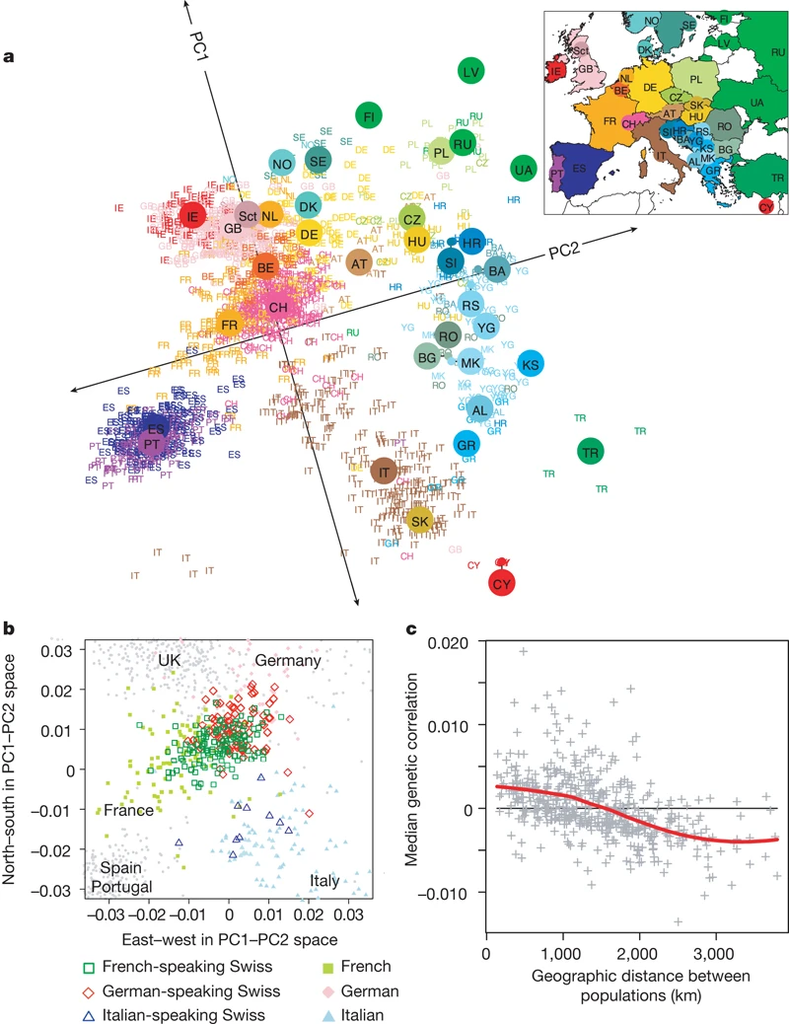

Novembre et al. 2008: the PCA redraws the map

## Populations do not mate at random

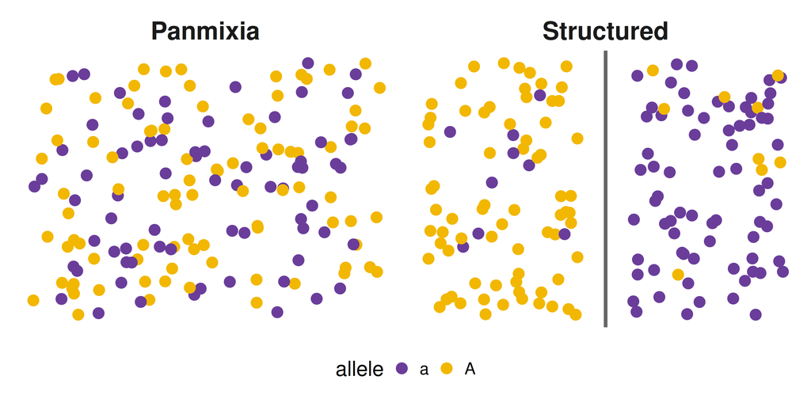

Subpopulations → different allele frequencies

## Why does it matter?

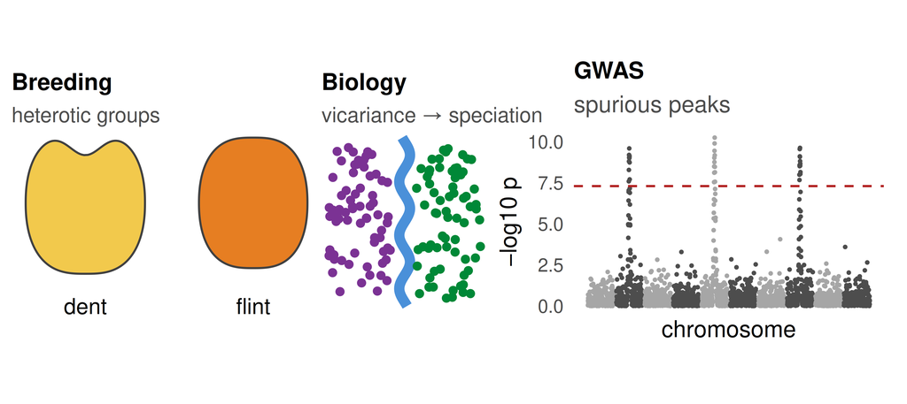

## Spurious association: type I error

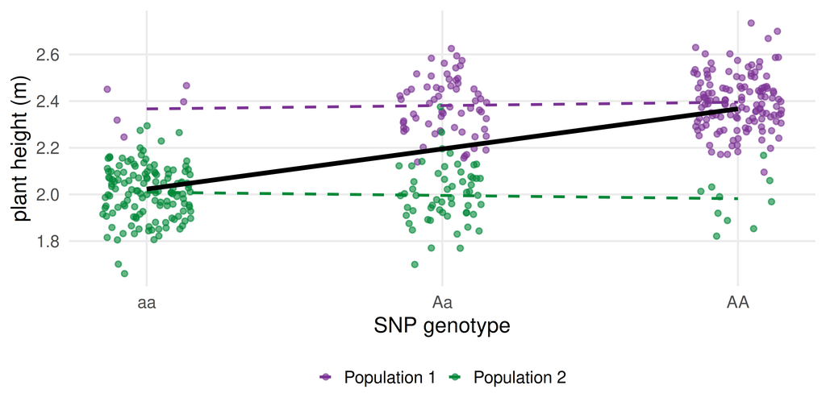

The SNP has no effect: the difference comes from the population

# The data: CornFed panels

## Dent × Flint: two heterotic groups

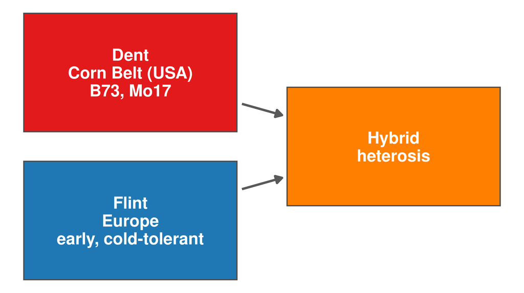

## One central line × 10–11 founders (+ 3 cross-pool families)

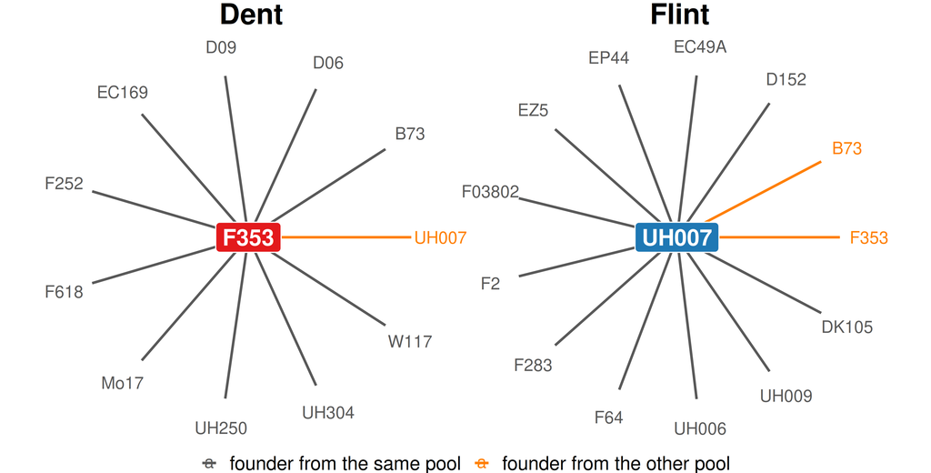

## Doubled haploid (DH) lines

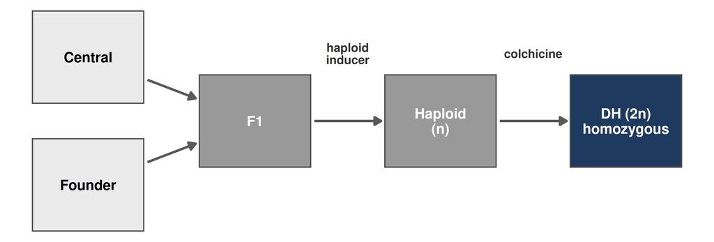

One meiosis · 50% central + 50% founder

## The data

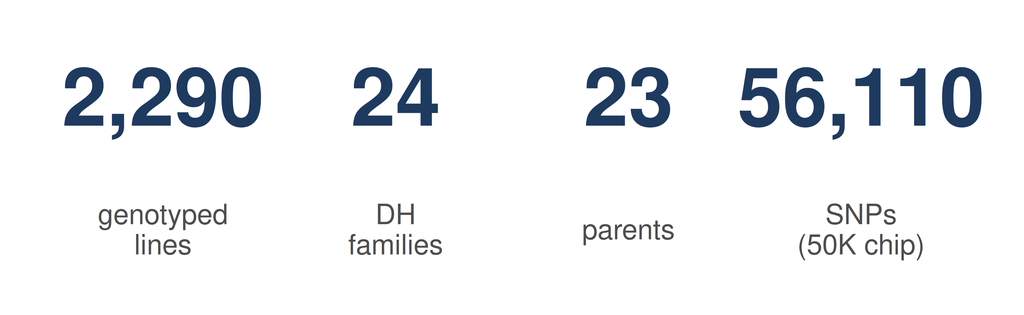

GEO **GSE50558** · Bauer et al. 2013 · Lehermeier et al. 2014

# From SNPs to clean data

## The chip reads two alleles: A and B

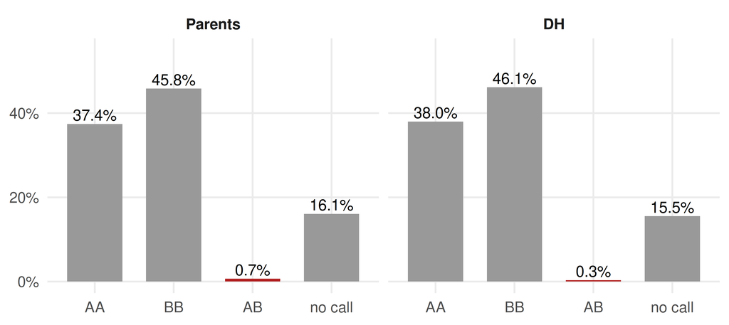

DH almost without AB → heterozygote = error → missing data

## PLINK: the Swiss army knife for SNPs

- file formats
- filters (QC)
- LD and pruning
- PCA, F<sub>ST</sub>

Built for **humans**: 22 autosomes + X, Y

**Maize**: 10 chromosomes, no sex chromosomes

```r
c("--chr-set", "10", "no-xy")
```

## SNPs have errors: filtering

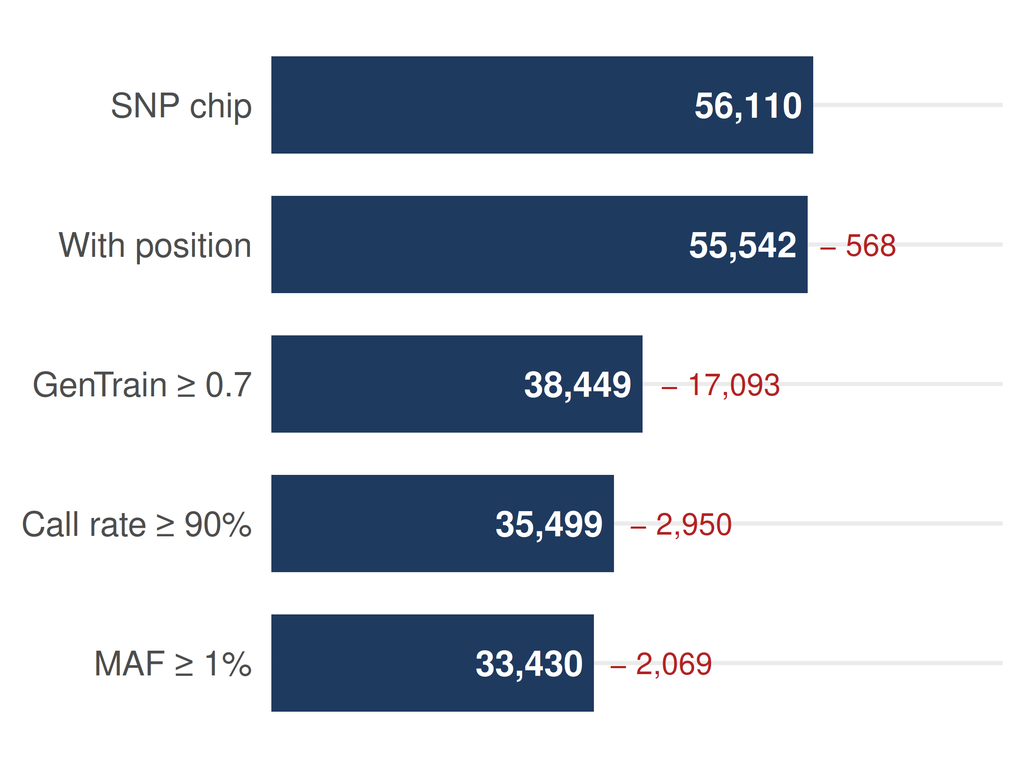

```r
rodar_plink(
  "--bfile", "cornfed_bruto",
  "--exclude",
    "gentrain_baixo.txt",
  "--remove",
    "dh_faltantes.txt",
  "--geno", "0.1",
  "--maf",  "0.01",
  "--make-bed",
  "--out", "cornfed_cq")
```

```
33430 variants and
2269 samples pass
```

## Linkage disequilibrium (LD)

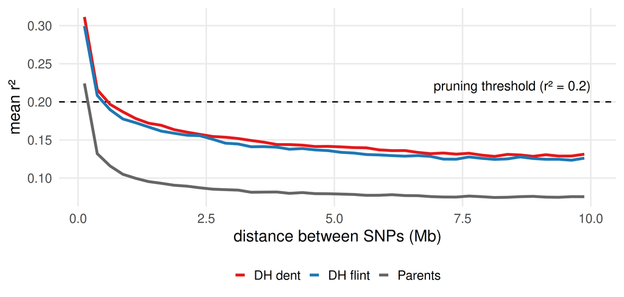

## LD pruning

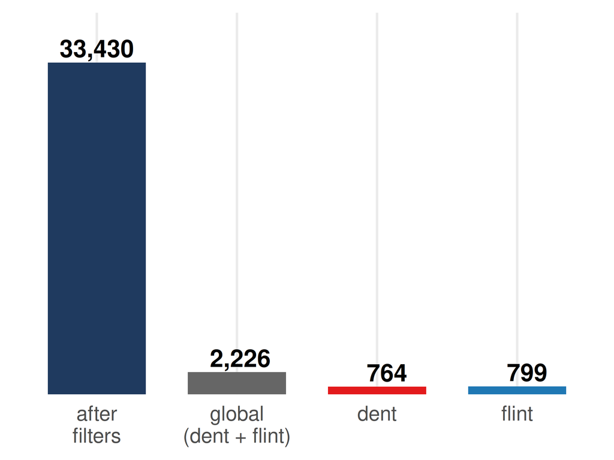

```r
# window 50, step 5,
# r² > 0.2 → one goes
rodar_plink(
  "--bfile", "cornfed_cq",
  "--keep",  "dent.txt",
  "--maf",   "0.01",
  "--geno",  "0.1",
  "--indep-pairwise",
    "50", "5", "0.2",
  "--out",   "dent")
```

# STRUCTURE

## The idea of the model

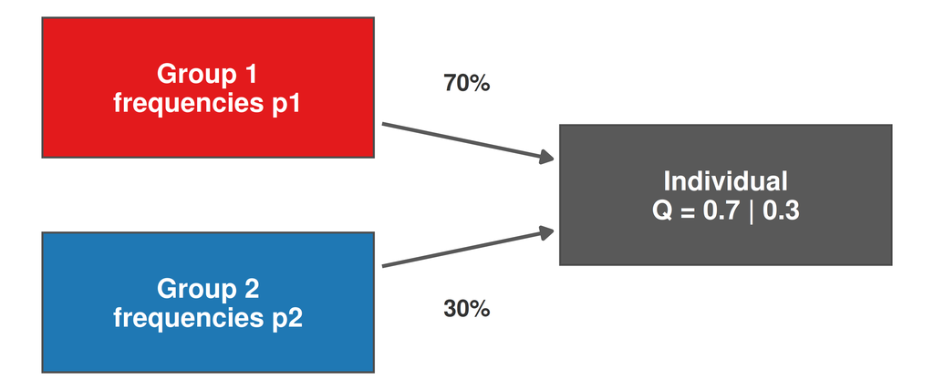

K groups in Hardy-Weinberg · Q = fraction from each group

## How STRUCTURE estimates P and Q

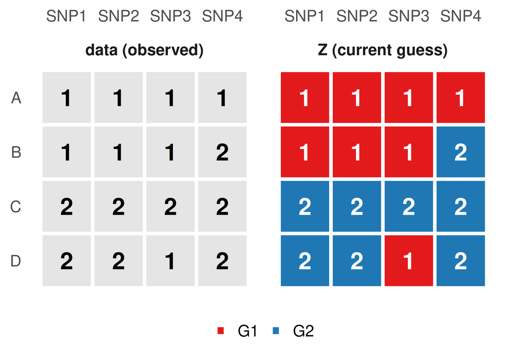

**P** from Z (SNP 3, allele 1)

|  | count | p |
| --- | --- | --- |
| G1 | 3 of 3 | (3+1)/(3+2) = 0.80 |
| G2 | 0 of 1 | (0+1)/(1+2) = 0.33 |

**Q** from Z (copies in G1)

| A | B | C | D |
| --- | --- | --- | --- |
| 1.00 | 0.75 | 0.00 | 0.25 |

Start: Z at random · Z → P and Q → Z → … (150,000 times)

## Then Z is re-drawn from P and Q

Each copy: chance of group k ∝ **q**(line, k) × **p**(k, allele)

| copy | G1 | G2 | chance G1 / G2 |
| --- | --- | --- | --- |
| D, SNP 3, allele 1 | 0.25 × 0.80 = 0.20 | 0.75 × 0.33 = 0.25 | **44% / 56%** |
| D, SNP 1, allele 2 | 0.25 × 0.25 = 0.06 | 0.75 × 0.75 = 0.56 | **10% / 90%** |

- Lines that share alleles **pull each other** into the same group
- After burn-in: **output = average** of P and Q over the iterations

Real data: ~10 million allele copies per iteration

## What STRUCTURE reads

```r
rodar_plink("--bfile", "cornfed_cq", "--keep", "dent.txt",
            "--extract", "dent.prune.in",
            "--recode", "structure", "--out", "dent")
```

```
PZE-101000088 PZE-101000209 PZE-101000451 ...   ← SNP names
-1 157033 604385 ...                            ← map distances (bp)
F353      1  2 2  2 2  2 2  2 2 ...
UH007     1  2 2  2 2  2 2  2 2 ...
CFD06-002 7  0 0  1 1  0 0  2 2 ...             ← 0 0 = missing
CFF15-141 25 2 2  2 2  1 1  2 2 ...
```

One row per line · family code · 2 columns per SNP (alleles 1/2)

## Parameters

| Parameter | Exploration | Cluster | Purpose |
| --- | --- | --- | --- |
| samples | 743 | 2,269 |  |
| K | 1–6 · 1–12 · 1–14 | 1–8 · 1–13 · 1–14 | groups tested |
| replicates | 3 | 5 | same answer? |
| BURNIN | 10,000 | 50,000 | discarded |
| NUMREPS | 20,000 | 100,000 | used |
| NOADMIX, FREQSCORR | 0, 1 | 0, 1 | model |
| RANDOMIZE | 0 + `-D` | 0 + `-D` | reproducible |

## MCMC: burn-in and convergence

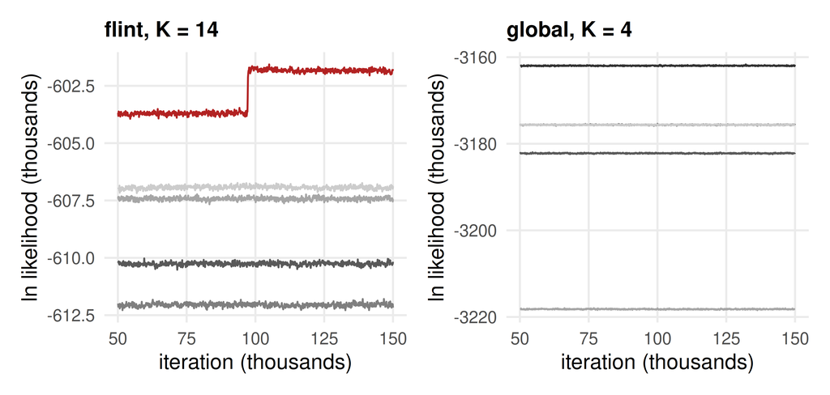

Jump → unstable replicate · different plateaus → several solutions

## Running it: from laptop to cluster

```r
# local: several runs in parallel, 1 core each
parallel::mclapply(1:96, rodar_structure, mc.cores = 10)
```

```bash
# UFV cluster (PBS): one job per dataset × K × replicate
qsub -N "$nome" -l walltime="$walltime" \
     -v CONJ=$conj,K=$k,REP=$rep,SEMENTE=$semente \
     structure_job.pbs
```

Local: 96 runs in 6.5 h · Cluster: 169 of 175 jobs

## The output: the Q matrix

| individual | family | Q group 1 | Q group 2 |
| --- | --- | --- | --- |
| B73 | parent | 0.20 | 0.80 |
| CFD01-003 | CFD01 | 0.61 | 0.39 |
| CFD03-003 | CFD03 | 0.00 | 1.00 |
| CFF09-001 | CFF09 | 1.00 | 0.00 |
| UH007 | parent | 1.00 | 0.00 |

One row per individual · sum = 1

## How to read the plot

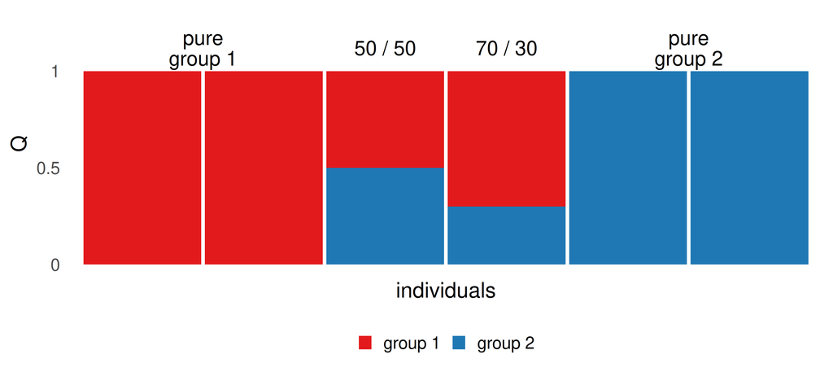

One bar = one individual · colours = fraction of the genome

# R: tying it all together

## One workflow, one script

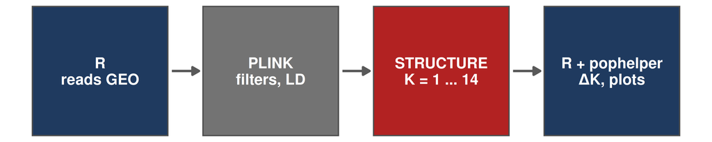

```r
q  <- readQ(arquivos_f)              # read the Q matrices
ev <- evannoMethodStructure(
        summariseQ(tabulateQ(q)))    # Evanno's ΔK
q  <- alignK(q, type = "within")     # align the replicates
```

# Results

## STRUCTURE output: global, K = 2

| replicate | mean ln L | var ln L | ln P(D\|K) = mean − var / 2 |
| --- | --- | --- | --- |
| 1 | -3,461,313.8 | 2,992.3 | -3,462,810.0 |
| 2 | -3,461,313.2 | 2,982.5 | -3,462,804.4 |
| 3 | -3,461,313.8 | 2,951.0 | -3,462,789.3 |
| 4 | -3,461,312.4 | 2,979.3 | -3,462,802.0 |
| 5 | -3,461,313.4 | 2,991.7 | -3,462,809.3 |
| **mean** |  |  | **-3,462,803.0** |
| **SD** |  |  | **8.36** |

**From replicates to ΔK**

L(K) = **mean**, s(K) = **SD** of ln P(D|K)

$$\Delta K = \frac{|L(K{+}1) - 2\,L(K) + L(K{-}1)|}{s(K)}$$

The next slide applies this formula to every K

## From ln P(D|K) to ΔK: global

| K | L(K) mean | s(K) SD | 1st derivative L(K) − L(K−1) *gain* | 2nd derivative \|L′(K+1) − L′(K)\| *change in gain* | ΔK 2nd deriv. / s(K) |
| --- | --- | --- | --- | --- | --- |
| 1 | -4,045,235 | 2.8 |  |  |  |
| **2** | **-3,462,803** | **8.4** | **582,432** | **413,355** | **49,463.7** |
| 3 | -3,293,726 | 1,651.4 | 169,077 | 60,510 | 36.6 |
| 4 | -3,185,158 | 21,224.5 | 108,568 | 4,061 | 0.19 |
| 5 | -3,072,530 | 31,750.8 | 112,629 | 382 | 0.01 |
| 6 | -2,959,518 | 28,559.8 | 113,011 | 16,180 | 0.57 |
| 7 | -2,862,688 |  | 96,831 | 24,056 |  |
| 8 | -2,789,912 | 19,208.3 | 72,775 |  |  |

Reminder · **admixture model**: each allele copy can come from a different group · **DH coded as diploid**: two identical copies → Q is **overconfident**; haploid coding (PLOIDY 1) would be more faithful

## How many groups? Evanno’s ΔK

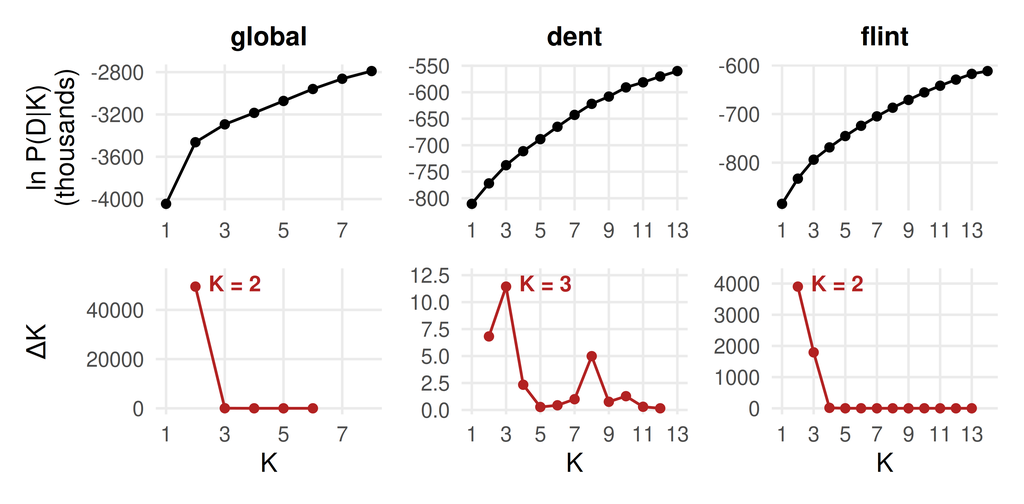

ΔK: K = 2 (global, flint) · K = 3 (dent)

## Do the replicates agree?

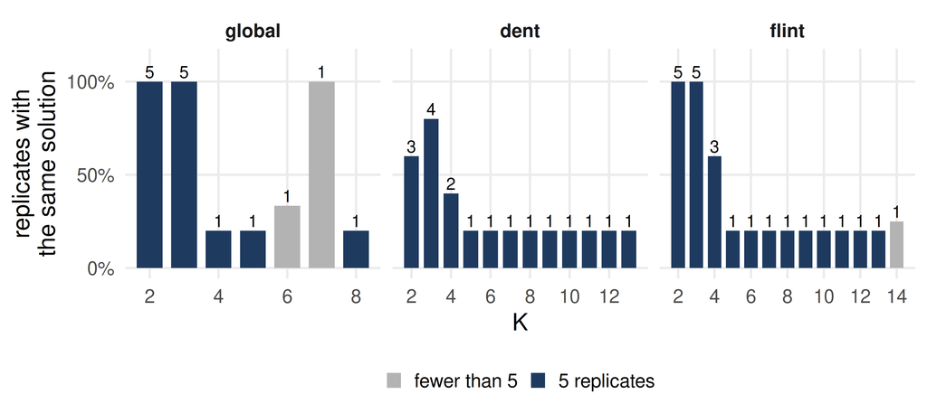

Only low K values are reproducible

## Global, K = 2: dent × flint

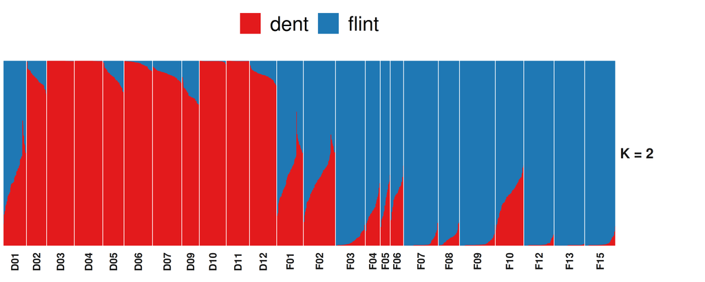

CFD01, CFF01, CFF02: ~60/40, their parents come from both pools

## Within the Dent pool

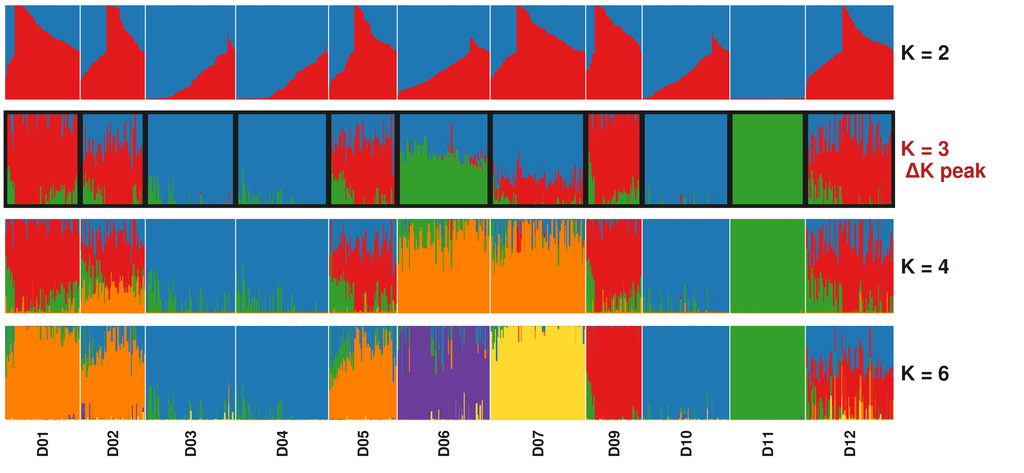

D11 = F353 × UH304: both Iodent, the most similar pair (SM = 0.77)

## Within the Flint pool

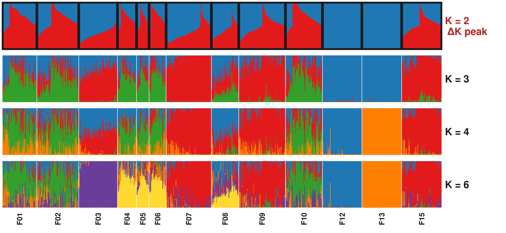

F12, F13: founders closest to UH007 (SM = 0.79 and 0.82)

## PCA: another view

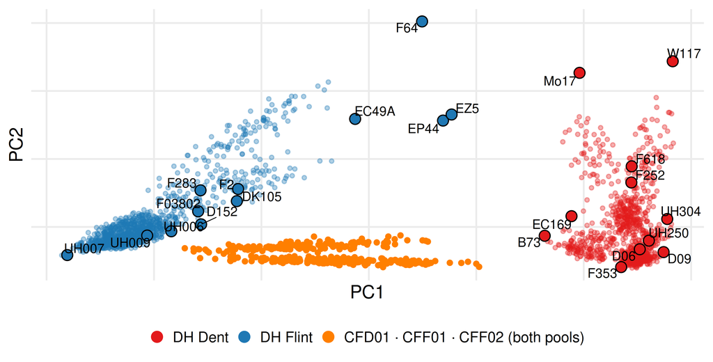

# F-statistics

## Wahlund effect

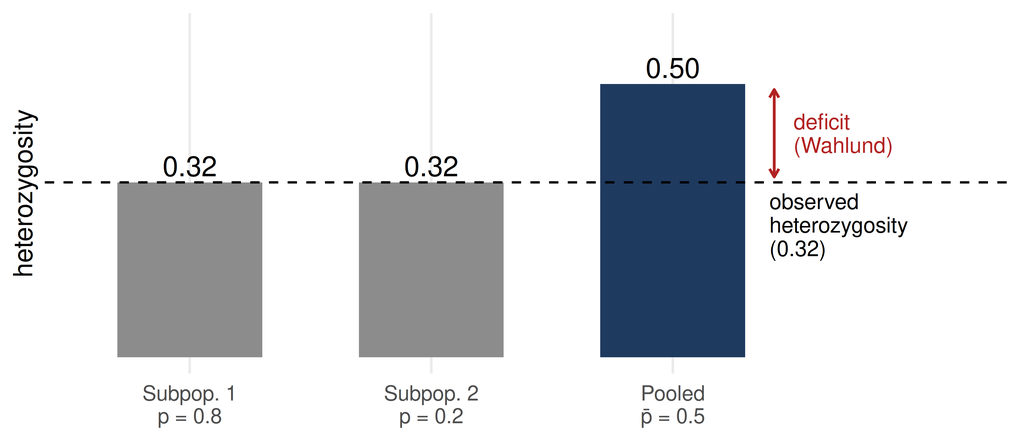

Pooling subpopulations → “missing” heterozygotes

## Wright’s F: three levels

$$\underbrace{F_{IS} = 1 - \frac{H_O}{H_S}}_{\text{within}} \qquad
\underbrace{F_{ST} = 1 - \frac{H_S}{H_T}}_{\text{between}} \qquad
\underbrace{F_{IT} = 1 - \frac{H_O}{H_T}}_{\text{total}}$$

$$(1 - F_{IT}) = (1 - F_{IS})\,(1 - F_{ST})$$

## F in the CornFed data

| subpopulations | H<sub>O</sub> | H<sub>S</sub> | H<sub>T</sub> | F<sub>IS</sub> | F<sub>ST</sub> | F<sub>IT</sub> |
| --- | --- | --- | --- | --- | --- | --- |
| Pools (dent × flint) | 0.001 | 0.247 | 0.310 | 0.998 | 0.202 | 0.998 |
| Dent families | 0.001 | 0.187 | 0.291 | 0.997 | 0.356 | 0.998 |
| Flint families | 0.001 | 0.161 | 0.247 | 0.996 | 0.348 | 0.998 |

**H<sub>O</sub>** observed heterozygosity (fraction of AB) · **H<sub>S</sub>** expected 2pq within each subpopulation · **H<sub>T</sub>** expected 2pq in the total  
**F<sub>IS</sub>** = 1 − H<sub>O</sub>/H<sub>S</sub> inbreeding within · **F<sub>ST</sub>** = 1 − H<sub>S</sub>/H<sub>T</sub> differentiation between · **F<sub>IT</sub>** = 1 − H<sub>O</sub>/H<sub>T</sub> total

F<sub>IS</sub> ≈ 1: DH lines are homozygous

F<sub>ST</sub> families **>** F<sub>ST</sub> pools

# Take-home

## What STRUCTURE found

1. **K = 2**: dent × flint, the historical split
2. Within a pool: **central line** × founders
3. Beyond that: **families**, i.e. the pedigree
4. In a breeder-built population, **there is no “true K”**

Structure ≠ only natural populations: relatedness is structure too

## References

**STRUCTURE**

- Pritchard 2000
- Falush 2003
- Evanno 2005
- Francis 2017

**Population genetics**

- Weir & Cockerham 1984
- Rosenberg 2002
- Yu 2006
- Novembre 2008

**Data and tools**

- Caniato 2011
- Bauer 2013
- Lehermeier 2014
- Chang 2015